# R4_External_Lab_Validation_Accuracy-Ans

### Q2.Prepare the model data by converting non-numeric to dummy ( 1 Marks)

##### Hint: Use get_dummies

```python
# Print Shape of model data
```

```python
df.shape
```

```
(1000, 21)
```

```python
df_=pd.get_dummies(df,drop_first=True)
```

```python
df_.head()
```

|  | default | duration_in_month | credit_amount | installment_as_income_perc | present_res_since | age | credits_this_bank | people_under_maintenance | account_check_status_< 0 DM | account_check_status_>= 200 DM / salary assignments for at least 1 year | ... | property_unknown / no property | other_installment_plans_none | other_installment_plans_stores | housing_own | housing_rent | job_skilled employee / official | job_unemployed/ unskilled - non-resident | job_unskilled - resident | telephone_yes, registered under the customers name | foreign_worker_yes |
| --- | --- | --- | --- | --- | --- | --- | --- | --- | --- | --- | --- | --- | --- | --- | --- | --- | --- | --- | --- | --- | --- |
| 0 | 0 | 6 | 1169 | 4 | 4 | 67 | 2 | 1 | 1 | 0 | ... | 0 | 1 | 0 | 1 | 0 | 1 | 0 | 0 | 1 | 1 |
| 1 | 1 | 48 | 5951 | 2 | 2 | 22 | 1 | 1 | 0 | 0 | ... | 0 | 1 | 0 | 1 | 0 | 1 | 0 | 0 | 0 | 1 |
| 2 | 0 | 12 | 2096 | 2 | 3 | 49 | 1 | 2 | 0 | 0 | ... | 0 | 1 | 0 | 1 | 0 | 0 | 0 | 1 | 0 | 1 |
| 3 | 0 | 42 | 7882 | 2 | 4 | 45 | 1 | 2 | 1 | 0 | ... | 0 | 1 | 0 | 0 | 0 | 1 | 0 | 0 | 0 | 1 |
| 4 | 1 | 24 | 4870 | 3 | 4 | 53 | 2 | 2 | 1 | 0 | ... | 1 | 1 | 0 | 0 | 0 | 1 | 0 | 0 | 0 | 1 |

5 rows × 49 columns

```python
df_.shape
```

```
(1000, 49)
```

### Check for highly correlated variables but don't required any treatment for this use case

```python
corr_df=df.corr()
```

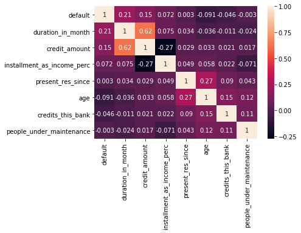

```python
sns.heatmap(corr_df,annot=True)
```

the variables duration_in_month and credit_amount are highly correlated variables.both variables are feeding same information to our model .droping one of these two variables lead to overcome the problem of cource of dimensionality.

```python
df_=df_.drop("duration_in_month",axis=1)
```

```python
df_.head(2)
```

|  | default | credit_amount | installment_as_income_perc | present_res_since | age | credits_this_bank | people_under_maintenance | account_check_status_< 0 DM | account_check_status_>= 200 DM / salary assignments for at least 1 year | account_check_status_no checking account | ... | property_unknown / no property | other_installment_plans_none | other_installment_plans_stores | housing_own | housing_rent | job_skilled employee / official | job_unemployed/ unskilled - non-resident | job_unskilled - resident | telephone_yes, registered under the customers name | foreign_worker_yes |
| --- | --- | --- | --- | --- | --- | --- | --- | --- | --- | --- | --- | --- | --- | --- | --- | --- | --- | --- | --- | --- | --- |
| 0 | 0 | 1169 | 4 | 4 | 67 | 2 | 1 | 1 | 0 | 0 | ... | 0 | 1 | 0 | 1 | 0 | 1 | 0 | 0 | 1 | 1 |
| 1 | 1 | 5951 | 2 | 2 | 22 | 1 | 1 | 0 | 0 | 0 | ... | 0 | 1 | 0 | 1 | 0 | 1 | 0 | 0 | 0 | 1 |

2 rows × 48 columns

### Q3 Split Train/Test data 70:30 ratio( 1 Marks)

##### Hint:from sklearn.model_selection import train_test_split

```python
from sklearn.model_selection import train_test_split
```

```python
y=df_.pop("default")
```

```python
x=df_
```

```python
y.head(2)
```

```
0    0
1    1
Name: default, dtype: int64
```

```python
x.head(2)
```

|  | credit_amount | installment_as_income_perc | present_res_since | age | credits_this_bank | people_under_maintenance | account_check_status_< 0 DM | account_check_status_>= 200 DM / salary assignments for at least 1 year | account_check_status_no checking account | credit_history_critical account/ other credits existing (not at this bank) | ... | property_unknown / no property | other_installment_plans_none | other_installment_plans_stores | housing_own | housing_rent | job_skilled employee / official | job_unemployed/ unskilled - non-resident | job_unskilled - resident | telephone_yes, registered under the customers name | foreign_worker_yes |
| --- | --- | --- | --- | --- | --- | --- | --- | --- | --- | --- | --- | --- | --- | --- | --- | --- | --- | --- | --- | --- | --- |
| 0 | 1169 | 4 | 4 | 67 | 2 | 1 | 1 | 0 | 0 | 1 | ... | 0 | 1 | 0 | 1 | 0 | 1 | 0 | 0 | 1 | 1 |
| 1 | 5951 | 2 | 2 | 22 | 1 | 1 | 0 | 0 | 0 | 0 | ... | 0 | 1 | 0 | 1 | 0 | 1 | 0 | 0 | 0 | 1 |

2 rows × 47 columns

```python
X_train,X_test,y_train,y_test=train_test_split(x,y,test_size=0.3,random_state=9999)
```

### Q4 Build Random Forest Model( 2 Marks)

#### Hint:from sklearn.ensemble import RandomForestClassifier using n_jobs=2,n_estimators=500,criterion="entropy",random_state=9999

```python
from sklearn.ensemble import RandomForestClassifier
from sklearn.metrics import confusion_matrix,f1_score,accuracy_score,recall_score,precision_score
```

```python
rfc=RandomForestClassifier( n_jobs=2,n_estimators=500,criterion="entropy",random_state=9999)
```

```python
rfc.fit(X_train,y_train)
```

```
RandomForestClassifier(bootstrap=True, class_weight=None, criterion='entropy',
                       max_depth=None, max_features='auto', max_leaf_nodes=None,
                       min_impurity_decrease=0.0, min_impurity_split=None,
                       min_samples_leaf=1, min_samples_split=2,
                       min_weight_fraction_leaf=0.0, n_estimators=500, n_jobs=2,
                       oob_score=False, random_state=9999, verbose=0,
                       warm_start=False)
```

```python
y_pre=rfc.predict(X_test)
```

[output not shown]

[output not shown]

##### Hint: Use confusion_matrix and accuracy_score

```python
confusion_matrix(y_test,y_pre)
```

```
array([[195,  15],
       [ 57,  33]], dtype=int64)
```

```python
f1_score(y_test,y_pre)
```

```
0.47826086956521735
```

### Q6 Show the list of the features importance( 1 Marks)

```python
fi=pd.DataFrame(rfc.feature_importances_,columns=["important"],index=X_train.columns)
```

```python
fi
```

|  | important |
| --- | --- |
| credit_amount | 0.122187 |
| installment_as_income_perc | 0.043605 |
| present_res_since | 0.045169 |
| age | 0.096783 |
| credits_this_bank | 0.024161 |
| people_under_maintenance | 0.015013 |
| account_check_status_< 0 DM | 0.035753 |
| account_check_status_>= 200 DM / salary assignments for at least 1 year | 0.009576 |
| account_check_status_no checking account | 0.067887 |
| credit_history_critical account/ other credits existing (not at this bank) | 0.022755 |
| credit_history_delay in paying off in the past | 0.011265 |
| credit_history_existing credits paid back duly till now | 0.020023 |
| credit_history_no credits taken/ all credits paid back duly | 0.013808 |
| purpose_business | 0.012482 |
| purpose_car (new) | 0.023070 |
| purpose_car (used) | 0.011990 |
| purpose_domestic appliances | 0.018338 |
| purpose_education | 0.004264 |
| purpose_furniture/equipment | 0.003069 |
| purpose_radio/television | 0.016417 |
| purpose_repairs | 0.001721 |
| purpose_retraining | 0.000602 |
| savings_... < 100 DM | 0.019380 |
| savings_100 <= ... < 500 DM | 0.011721 |
| savings_500 <= ... < 1000 DM | 0.007098 |
| savings_unknown/ no savings account | 0.016002 |
| present_emp_since_... < 1 year | 0.016119 |
| present_emp_since_1 <= ... < 4 years | 0.021420 |
| present_emp_since_4 <= ... < 7 years | 0.014908 |
| present_emp_since_unemployed | 0.013258 |
| personal_status_sex_male : divorced/separated | 0.008181 |
| personal_status_sex_male : married/widowed | 0.010059 |
| personal_status_sex_male : single | 0.021405 |
| other_debtors_guarantor | 0.010437 |
| other_debtors_none | 0.012570 |
| property_if not A121/A122 : car or other, not in attribute 6 | 0.021525 |
| property_real estate | 0.018590 |
| property_unknown / no property | 0.017780 |
| other_installment_plans_none | 0.028927 |
| other_installment_plans_stores | 0.009352 |
| housing_own | 0.018525 |
| housing_rent | 0.014694 |
| job_skilled employee / official | 0.021505 |
| job_unemployed/ unskilled - non-resident | 0.004023 |
| job_unskilled - resident | 0.014071 |
| telephone_yes, registered under the customers name | 0.022881 |
| foreign_worker_yes | 0.005631 |

### Q7 K-fold cross-validation( 2 Marks)

##### k-fold cross validation( without stratification)

##### Usually k is set as 10-20 in practical settings, depends on data set size

```python
from sklearn.model_selection import KFold
from sklearn.model_selection import cross_val_score
```

```python
# Use below values
num_folds = 10
seed = 77
```

```python
y.shape
```

```
(1000,)
```

```python
y.head()
```

```
0    0
1    1
2    0
3    0
4    1
Name: default, dtype: int64
```

```python
#Validate the Random Forest model build above using k fold
```

```python
kf = KFold(n_splits=10)
kf.get_n_splits(x,y)
print(kf)
KFold(n_splits=10, random_state=77)
```

```
KFold(n_splits=10, random_state=None, shuffle=False)
```

```
KFold(n_splits=10, random_state=77, shuffle=False)
```

```python
#Calculate Mean score
```

```python
score=cross_val_score(RandomForestClassifier(),x,y)
```

```python
print(score)
```

[output not shown]

```python
score.mean()
```

[output not shown]

```python
# Calculate score standard deviation using std()
```

```python
score.std()
```

```
0.008848746046791367
```

# Q8 Build Ada boosting model, check the accuracy, and print confusion matrix ( 1 Marks)

```python
from sklearn.tree import DecisionTreeClassifier
from sklearn.ensemble import AdaBoostClassifier
```

```python
ada_clf=AdaBoostClassifier(DecisionTreeClassifier(max_depth=1),n_estimators=100,algorithm="SAMME",learning_rate=1.0)
ada_clf.fit(X_train,y_train)
```

```
AdaBoostClassifier(algorithm='SAMME',
                   base_estimator=DecisionTreeClassifier(class_weight=None,
                                                         criterion='gini',
                                                         max_depth=1,
                                                         max_features=None,
                                                         max_leaf_nodes=None,
                                                         min_impurity_decrease=0.0,
                                                         min_impurity_split=None,
                                                         min_samples_leaf=1,
                                                         min_samples_split=2,
                                                         min_weight_fraction_leaf=0.0,
                                                         presort=False,
                                                         random_state=None,
                                                         splitter='best'),
                   learning_rate=1.0, n_estimators=100, random_state=None)
```

```python
ada_clf.estimator_weights_
```

```
array([0.84729786, 0.73787322, 0.45049049, 0.20106125, 0.32149729,
       0.29610044, 0.09729993, 0.16985178, 0.29523442, 0.2624681 ,
       0.23845714, 0.24994648, 0.0912461 , 0.06946076, 0.12117855,
       0.15018882, 0.15516795, 0.20805336, 0.27781978, 0.09668569,
       0.14680953, 0.12598581, 0.18972699, 0.04480106, 0.0511051 ,
       0.04930432, 0.08929728, 0.19852826, 0.18678174, 0.04322362,
       0.04907773, 0.03343234, 0.0862825 , 0.08092154, 0.03029786,
       0.0298457 , 0.02940683, 0.02898068, 0.02856671, 0.0281644 ,
       0.02777327, 0.02739285, 0.02702271, 0.02666245, 0.02631166,
       0.02596998, 0.15078106, 0.12719275, 0.09756644, 0.03686472,
       0.05363755, 0.07703613, 0.10505841, 0.02376607, 0.02348696,
       0.02321433, 0.02711784, 0.10968729, 0.10013704, 0.07808292,
       0.06750788, 0.02329032, 0.02302221, 0.02276021, 0.02657447,
       0.09675767, 0.10163514, 0.02267911, 0.02242481, 0.02217615,
       0.02193295, 0.02169502, 0.0214622 , 0.02123432, 0.02101123,
       0.02079278, 0.02057883, 0.02036924, 0.02016387, 0.0199626 ,
       0.02590454, 0.04433914, 0.01959041, 0.01940037, 0.01921399,
       0.05901174, 0.05582924, 0.02517143, 0.04187707, 0.03045774,
       0.02966707, 0.01731521, 0.01716659, 0.01702049, 0.11235972,
       0.10984449, 0.04419491, 0.01711944, 0.01697414, 0.01683129])
```

```python
y_pre1=ada_clf.predict(X_test)
print("accuracy scpore\n",accuracy_score(y_test,y_pre1))
print("confusion matrix\n",confusion_matrix(y_test,y_pre1))
print("f1_score\n",f1_score(y_test,y_pre1))
```

```
accuracy scpore
 0.7433333333333333
confusion matrix
 [[187  23]
 [ 54  36]]
f1_score
 0.48322147651006714
```

# Q9. Build Gradient boosting model, check the accuracy, and print confusion matrix ( 1 Marks)

percentage of correct predictions and Calculate sensitivity (or True Positive Rate or Recall) and Precision. ( 1 Marks)

```python
from sklearn.ensemble import GradientBoostingClassifier
```

```python
y_train.head()
```

```
791    0
839    0
598    1
920    0
551    0
Name: default, dtype: int64
```

```python
gbc=GradientBoostingClassifier(max_depth=3,n_estimators=100,learning_rate=0.1)
```

```python
gbc.fit(X_train,y_train)
```

```
GradientBoostingClassifier(criterion='friedman_mse', init=None,
                           learning_rate=0.1, loss='deviance', max_depth=3,
                           max_features=None, max_leaf_nodes=None,
                           min_impurity_decrease=0.0, min_impurity_split=None,
                           min_samples_leaf=1, min_samples_split=2,
                           min_weight_fraction_leaf=0.0, n_estimators=100,
                           n_iter_no_change=None, presort='auto',
                           random_state=None, subsample=1.0, tol=0.0001,
                           validation_fraction=0.1, verbose=0,
                           warm_start=False)
```

```python
y_pre2=gbc.predict(X_test)
```

```python
print("confusion matrix\n",confusion_matrix(y_test,y_pre2))
print("accuracy score\n",accuracy_score(y_test,y_pre2))
print("f1 score\n",f1_score(y_test,y_pre2))
print("recall\n",recall_score(y_test,y_pre2))
print("precision\n",precision_score(y_test,y_pre2))
```

```
confusion matrix
 [[184  26]
 [ 57  33]]
accuracy score
 0.7233333333333334
f1 score
 0.44295302013422816
recall
 0.36666666666666664
precision
 0.559322033898305
```

### Bootstrapping ( Bonus)

##### Given a dataset of size n, a bootstrap sample is created by sampling n instances uniformly from the data (with/without replacement)

##### Create a model with each bootstrap sample and validate it with the test set

##### Final result is calculated by averaging the accuracy of models

```python
# Number of iterations for bootstrapping
bootstrap_iteration = 10
accuracy = []
```

```python
from sklearn.utils import resample
from sklearn.metrics import accuracy_score

for i in range(bootstrap_iteration):
    X_, y_ = resample(X_train, y_train)
    gbc.fit(X_, y_)
    y_pred = gbc.predict(X_test)

    acc = accuracy_score(y_pred, y_test)
    accuracy.append(acc)
```

```python
accuracy = np.array(accuracy)
print('Accuracy Score   ',accuracy)
print('Avearge: ', accuracy.mean())
print('Standard deviation: ', accuracy.std())
```

```
Accuracy Score    [0.70666667 0.71       0.73666667 0.71       0.71       0.72
 0.72333333 0.73333333 0.74333333 0.71666667]
Avearge:  0.721
Standard deviation:  0.012206555615733704
```